# 노년층의 경제 상태 분석 - 소득, 지출, 부담이 되는 지출 항목

출처 : https://kosis.kr/index/index.do

```python
def get_cursor():
    conn=pymysql.connect(host='localhost', user='root', password='ibgdrgn0818', db='team', charset='utf8')

    cur=conn.cursor()

    return cur
```

```python
import pymysql
import pandas as pd
import matplotlib.pyplot as plt
import platform
```

```python
if platform.system()=='Windows':
    plt.rc('font', family='Malgun Gothic')
else:
    plt.rc('font', family='AppleGothic')
```

```python
large_char_list=['가구형태별', '결혼상태별', '교육수준별', '성별', '연령별']
```

### 소득

```python
def get_income(large_char):
    cur=get_cursor()

    if large_char=='가구형태별':
        sql="""
        select 대특성, 소특성, avg(근로소득) 근로소득, avg(사업소득) 사업소득,
        avg(재산소득) 재산소득, avg(사적이전소득) 사적이전소득, avg(공적이전소득), avg(사적이전소득) from income
        group by 대특성, 소특성
        having 대특성=%s and 소특성 in ('노인독거', '노인부부', '자녀동거')
        order by 1, 2
        """

        cur.execute(sql, large_char)
        rows=cur.fetchall()
        income_df[large_char]=pd.DataFrame(rows, columns=['대특성', '소특성', '근로소득', '사업소득', '재산소득', '사적이전소득', '공적이전소득', '사적연금소득'])
        income_df[large_char]=income_df[large_char].set_index(['대특성', '소특성'])

    else:
        sql="""
        select 대특성, 소특성, avg(근로소득) 근로소득, avg(사업소득) 사업소득,
        avg(재산소득) 재산소득, avg(사적이전소득) 사적이전소득,
        avg(공적이전소득) 공적이전소득, avg(사적연금소득) 사적연금소득 from income
        group by 대특성, 소특성
        having 대특성=%s
        order by 1, 2
        """
        cur.execute(sql, large_char)
        rows=cur.fetchall()
        income_df[large_char]=pd.DataFrame(rows, columns=['대특성', '소특성', '근로소득', '사업소득', '재산소득', '사적이전소득', '공적이전소득', '사적연금소득'])
        income_df[large_char]=income_df[large_char].set_index(['대특성', '소특성'])

    cur.close()
```

```python
large_char_list=['가구형태별', '결혼상태별', '교육수준별', '성별', '연령별']
income_df={}

for large_char in large_char_list:
    get_income(large_char)

cur.close()
print(income_df.keys())
```

```
dict_keys(['가구형태별', '결혼상태별', '교육수준별', '성별', '연령별'])
```

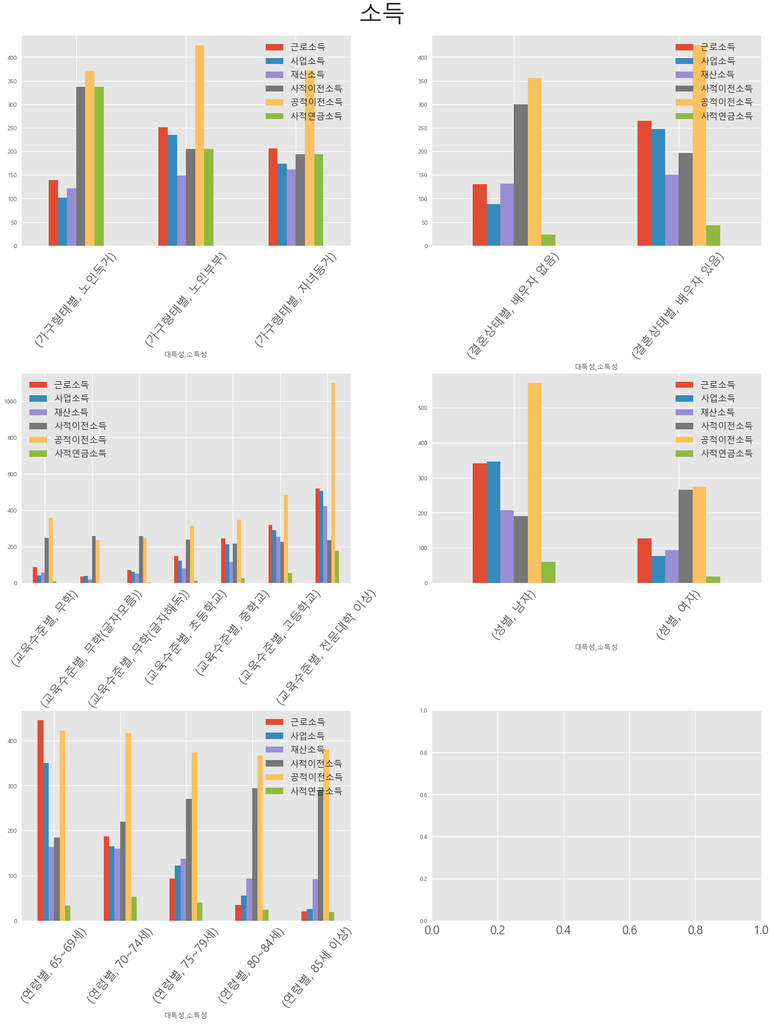

```python
plt.style.use('ggplot')
fig, axes=plt.subplots(3, 2)
plt.rc('font', size=15)
plt.rc('xtick', labelsize=20)
#plt.rc('axes', labelsize=3)
fig.tight_layout()
#plt.legend(bbox_to_anchor=(1.05, 1.0), loc='upper left')
fig.suptitle('소득', fontsize=40)
plt.rc('legend', fontsize=15)

for i in range(5):
    if i==4:
        income_df[large_char_list[i]].plot(kind='bar', figsize=(20, 25), ax=axes[i//2, i%2], rot=50)
        axes[i//2, i%2].legend(loc=1)
    elif i==2:
        income_df[large_char_list[i]].iloc[[1, 2, 3, 6, 5, 0, 4]].plot(kind='bar', figsize=(20, 25), ax=axes[i//2, i%2], rot=50)
    else:
        income_df[large_char_list[i]].plot(kind='bar', figsize=(20, 25), ax=axes[i//2, i%2], rot=50)
```

독거노인, 배우자가 없는 노인이 근로소득, 사업소득이 낮음 => 독거노인에게 일자리 제공 필요

학력이 높을수록 근로,사업,공적이전소득이 높음 => 어르신들의 교육수준을 높여서 일자리를 찾는데 도움이 될만한 방안 마련

여성보다 남성의 소득이 높음 => 여성들에 좀 더 초점을맞춘다면 노년층의 소득불균형 해소 가능

연령이 높아질수록 근로, 사업소득이 현저하게 낮아짐. => 75세 이상의 노년층에게 일할 기회 필요

젊은층에게 연금의 중요성 홍보 필요

### 지출

```python
def get_expense(large_char):
    cur=get_cursor()

    if large_char=='가구형태별':
        sql="""
        select 대특성, 소특성, avg(소비지출금액) as 소비지출금액, avg(주거비지출금액) 주거비지출금액 from expense
        group by 대특성, 소특성
        having 대특성=%s and 소특성 in ('노인독거', '노인부부', '자녀동거')
        order by 1, 2
        """

    else:
        sql="""
        select 대특성, 소특성, avg(소비지출금액) as 소비지출금액, avg(주거비지출금액) 주거비지출금액 from expense
        group by 대특성, 소특성
        having 대특성=%s
        order by 1, 2
        """

    cur.execute(sql, large_char)
    rows=cur.fetchall()
    expense_df[large_char]=pd.DataFrame(rows, columns=['대특성', '소특성', '소비지출금액', '주거비지출금액'])
    expense_df[large_char]=expense_df[large_char].set_index(['대특성', '소특성'])
    expense_df[large_char]=expense_df[large_char].astype('float')
```

```python
large_char_list=['가구형태별', '결혼상태별', '교육수준별', '성별', '연령별']
expense_df={}

for large_char in large_char_list:
    get_expense(large_char)

cur.close()
```

```
No artists with labels found to put in legend.  Note that artists whose label start with an underscore are ignored when legend() is called with no argument.
```

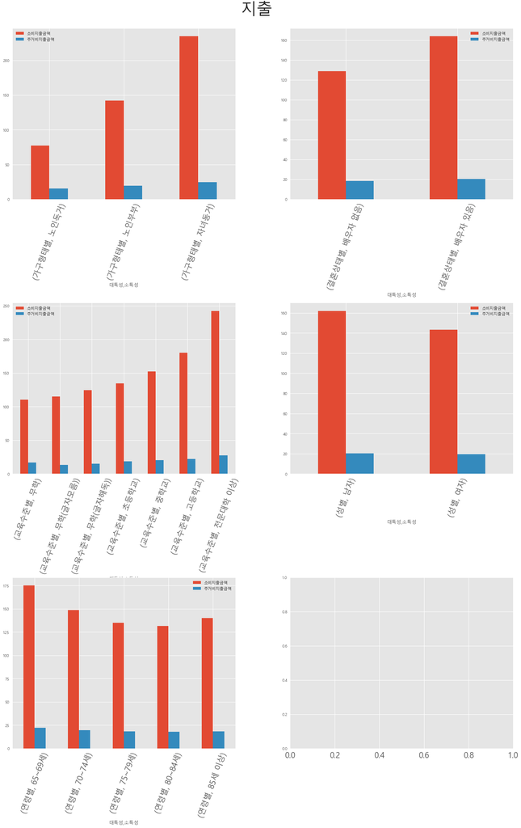

```python
plt.style.use('ggplot')
if platform.system()=='Windows':
    plt.rc('font', family='Malgun Gothic')
else:
    plt.rc('font', family='AppleGothic')

fig, axes=plt.subplots(3, 2)
plt.rc('font', size=15)
plt.rc('xtick', labelsize=20)
fig.tight_layout()
plt.legend()
fig.suptitle('지출', fontsize=40)


for i in range(5):
    if i==2:
        expense_df[large_char_list[i]].iloc[[1, 2, 3, 6, 5, 0, 4]].plot(kind='bar', figsize=(20, 30), ax=axes[i//2, i%2], rot=70)
    else:
        expense_df[large_char_list[i]].plot(kind='bar', figsize=(20, 30), ax=axes[i//2, i%2], rot=70)
```

누군가와 함께 살수록 지출이 커짐

하지만 소득 부문을 봤을 때 누군가와 함깨 사는 사람들이 소득도 높음

=> 큰 특이점 없음

### 부담을 느끼는 지출 항목

```python
def get_burden(large_char):
    cur=get_cursor()

    if large_char=='가구형태별':
        sql="""
        select 대특성, 소특성, avg(식비) as 식비, avg(주거관련비) 주거관련비, avg(보건의료비) 보건의료비,
        avg(월세) 월세, avg(경조사비) 경조사비 from burden
        group by 대특성, 소특성
        having 대특성=%s and 소특성!='기타'
        order by 1, 2
        """

    else:
        sql="""
        select 대특성, 소특성, avg(식비) as 식비, avg(주거관련비) 주거관련비, avg(보건의료비) 보건의료비,
        avg(월세) 월세, avg(경조사비) 경조사비 from burden
        group by 대특성, 소특성
        having 대특성=%s
        order by 1, 2
        """

    cur.execute(sql, large_char)
    rows=cur.fetchall()
    burden_df[large_char]=pd.DataFrame(rows, columns=['대특성', '소특성', '식비', '주거관련비', '보건의료비', '월세', '경조사비'])
    burden_df[large_char]=burden_df[large_char].set_index(['대특성', '소특성'])
    burden_df[large_char]=burden_df[large_char].astype('float')

    cur.close()
```

```python
large_char_list=['가구형태별', '결혼상태별', '교육수준별', '성별', '연령별']
burden_df={}

for large_char in large_char_list:
    get_burden(large_char)

print(burden_df.keys())
```

```
dict_keys(['가구형태별', '결혼상태별', '교육수준별', '성별', '연령별'])
```

```
No artists with labels found to put in legend.  Note that artists whose label start with an underscore are ignored when legend() is called with no argument.
```

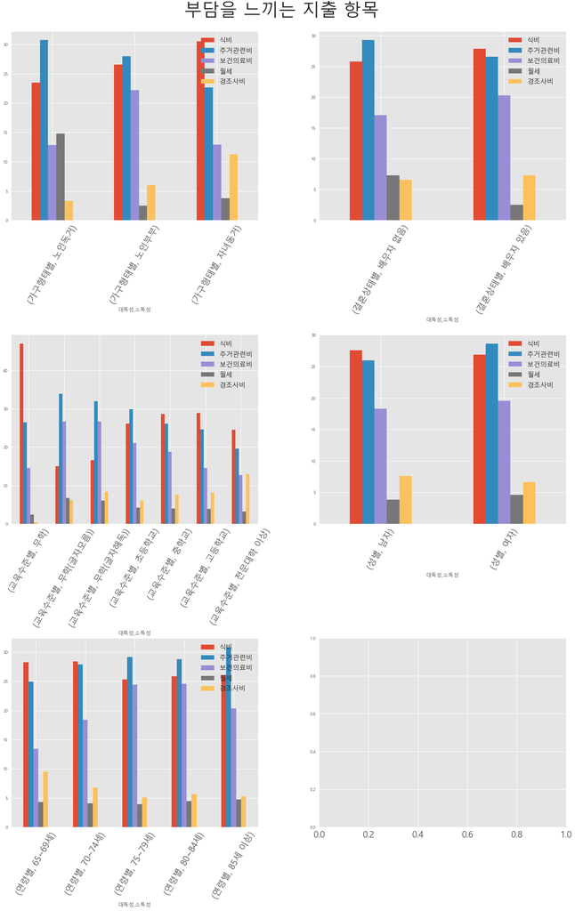

```python
plt.style.use('ggplot')
if platform.system()=='Windows':
    plt.rc('font', family='Malgun Gothic')
else:
    plt.rc('font', family='AppleGothic')

fig, axes=plt.subplots(3, 2)
plt.rc('font', size=15)
plt.rc('xtick', labelsize=20)
fig.tight_layout()
plt.legend()
fig.suptitle('부담을 느끼는 지출 항목', fontsize=40)


for i in range(5):
    if i==2:
        burden_df[large_char_list[i]].iloc[[1, 2, 3, 6, 5,0, 4]].plot(kind='bar', figsize=(20, 30), ax=axes[i//2, i%2], rot=60)
    else:
        burden_df[large_char_list[i]].plot(kind='bar', figsize=(20, 30), ax=axes[i//2, i%2], rot=60)
```

독거노인, 배우자가 없는 노인 : 월세 부담이 큼 => 독거노인을 위한 월세 지원

무학인 노인의 식비 부담이 높음 => 식비 지원